# Project proposal

P. Melloy

08/08/2019

##Trial overview  
A preliminary analysis of data collated for a meta-analysis of fungicide efficacy controlling Powdery Mildew (PM) in Mungbean has indicated there is more separation in the efficacy of fungicides to save yield loss from PM.

Active ingredient Propiconazole as shown better efficacy than the industry standard Tebeconazole, which potentially provides the least protection to crop yields in a comparison of six fungicide mixes. Propiconazole, Tebeconazole, Azoxystrobin + cyproconazole (Amistar extra), 200 g/l Tebuconazole + 120 g/l Azoxystrobin, Sulphur and Carbendazim.

Fungicide effect on proportion of yield gain

| Fungicide | total_Fungicide | n | lower_2.5 | median | mean | upper_97.5 |
| --- | --- | --- | --- | --- | --- | --- |
| propiconazole | 2 | 27 | -0.2440117 | 0.2078036 | 0.1694097 | 0.4020750 |
| Amistar | 2 | 12 | -0.1355750 | 0.1565000 | 0.1451250 | 0.3618250 |
| 200 g/l Tebuconazole + 120 g/l Azoxystrobin | 2 | 18 | -0.1450201 | 0.1543481 | 0.1560371 | 0.5064306 |
| propiconazole | 1 | 26 | -0.1470885 | 0.1389556 | 0.1542849 | 0.4675558 |
| Sulphur | 2 | 38 | -0.1043796 | 0.1360174 | 0.1232246 | 0.3757000 |
| 200 g/l Tebuconazole + 120 g/l Azoxystrobin | 1 | 18 | -0.1130254 | 0.1173908 | 0.1080364 | 0.3452196 |
| Tebeconazole | 3 | 5 | -0.2219250 | 0.0815000 | 0.0217925 | 0.1640073 |
| Amistar | 1 | 18 | -0.0345500 | 0.0805000 | 0.1360000 | 0.3877750 |
| Tebeconazole | 2 | 36 | -0.0592511 | 0.0768373 | 0.0992563 | 0.2905328 |
| Carbendazim | 1 | 10 | -0.0757270 | 0.0460346 | 0.0526670 | 0.2006309 |
| Tebeconazole | 1 | 36 | -0.1402926 | 0.0373804 | 0.0801616 | 0.3856324 |
| Sulphur | 3 | 7 | -0.2147527 | 0.0252560 | -0.0117257 | 0.1444500 |
| Sulphur | 1 | 34 | -0.1882838 | 0.0130000 | 0.0174492 | 0.1818323 |
| control | 0 | 52 | 0.0000000 | 0.0000000 | 0.0000000 | 0.0000000 |
| Carbendazim | 2 | 5 | NA | NA | NaN | NA |

Two Propiconazole sprays showed the highest median proportional yield saved with two sprays of Azoxystrobin + cyproconazole or Azoxystrobin + cyproconazole showing the next highest median. The combination of Stobin and Triazole fungicides show better efficacy to most other alternatives, excluding propiconazole. Surprisingly single sprays of of propiconazole, Tebeconazole + Azoxystobin and Azoxystrobin + cyproconazole on average out performed two sprays of tebeconazole. In fact two sprays of sulphur resulted in better average yields than two sprays of Tebeconazole.

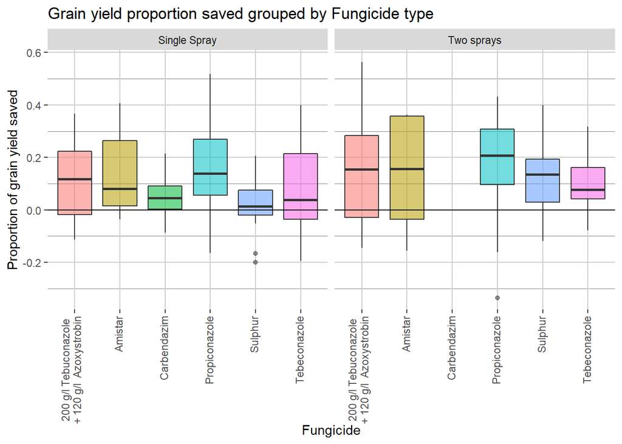

We propose further work to investigate the efficacy of these fungicides and Triazole strobin mixtures to evaluate best fungicide control options for growers. This work will also provide data to assist in registration of alternative fungicide products for growers to use thereby reducing the reliance on a handful of fungicides to control powdery mildew.  
In addition, recent development of the powdery mildew management tool has presented a best practice for managing powdery mildew in Mungbean for timing of application. With this new desicion support system it presents an excellent oportunity to capitalise on the knowledge of past trials to effectivley undertake an evaluation of fungicide efficacy between registered and unregistered products.